# IODS course project

# Cross-validating

We can do cross-validation natively with rms package.

```r
validate(mod2, method="crossvalidation", B=10)
```

```
##           index.orig training    test optimism index.corrected  n
## Dxy           0.5188   0.5198  0.4647   0.0551          0.4637 10
## R2            0.2625   0.2646  0.2510   0.0136          0.2489 10
## Intercept     0.0000   0.0000 -0.0723   0.0723         -0.0723 10
## Slope         1.0000   1.0000  0.9555   0.0445          0.9555 10
## Emax          0.0000   0.0000  0.0236   0.0236          0.0236 10
## D             0.2010   0.2026  0.1772   0.0254          0.1756 10
## U            -0.0052  -0.0058  0.0284  -0.0342          0.0290 10
## Q             0.2062   0.2084  0.1488   0.0596          0.1466 10
## B             0.1634   0.1629  0.1718  -0.0089          0.1722 10
## g             1.2971   1.3082  1.2587   0.0496          1.2476 10
## gp            0.2252   0.2254  0.2015   0.0239          0.2012 10
```

Which shows optimism in original model without cross validation (e.g. in Somer’s D)

We can also include all variables to the model and perform backwards stepwise regression in rms package:

```r
# Add all variables to the model (excluding those that were used to create the outcome variable)
mod3<-lrm(high_use~., data=alc[,-c("alc_use","Dalc","Walc"),with=F],x=T, y=T)

validate(mod3, method="crossvalidation", B=10, bw=T, pr=F)
```

```
##
##      Backwards Step-down - Original Model
##
##  Deleted    Chi-Sq d.f. P      Residual d.f. P      AIC
##  Mjob        4.57  4    0.3339  4.57     4   0.3339  -3.43
##  Fjob        4.59  4    0.3316  9.17     8   0.3284  -6.83
##  internet    0.00  1    0.9707  9.17     9   0.4219  -8.83
##  schoolsup   0.01  1    0.9086  9.18    10   0.5150 -10.82
##  G3          0.03  1    0.8710  9.21    11   0.6027 -12.79
##  higher      0.05  1    0.8278  9.26    12   0.6810 -14.74
##  Pstatus     0.05  1    0.8156  9.31    13   0.7492 -16.69
##  age         0.08  1    0.7816  9.39    14   0.8055 -18.61
##  failures    0.18  1    0.6746  9.56    15   0.8463 -20.44
##  Fedu        0.21  1    0.6490  9.77    16   0.8784 -22.23
##  famsup      0.37  1    0.5408 10.14    17   0.8975 -23.86
##  reason      4.56  3    0.2071 14.70    20   0.7931 -25.30
##  school      0.31  1    0.5795 15.01    21   0.8224 -26.99
##  romantic    0.46  1    0.4994 15.47    22   0.8415 -28.53
##  nursery     0.50  1    0.4781 15.97    23   0.8566 -30.03
##  freetime    0.74  1    0.3884 16.71    24   0.8606 -31.29
##  famsize     0.99  1    0.3186 17.71    25   0.8545 -32.29
##  guardian    2.99  2    0.2247 20.69    27   0.8004 -33.31
##  health      1.66  1    0.1975 22.35    28   0.7646 -33.65
##  traveltime  2.10  1    0.1469 24.46    29   0.7060 -33.54
##  Medu        8.39  4    0.0783 32.85    33   0.4746 -33.15
##  paid        1.82  1    0.1768 34.67    34   0.4357 -33.33
##  studytime   2.71  1    0.0995 37.39    35   0.3600 -32.61
##  G2          3.14  1    0.0762 40.53    36   0.2772 -31.47
##  G1          0.68  1    0.4103 41.21    37   0.2916 -32.79
##  address     3.76  1    0.0524 44.97    38   0.2030 -31.03
##  activities  3.88  1    0.0490 48.85    39   0.1341 -29.15
##  famrel      5.79  1    0.0161 54.64    40   0.0613 -25.36
##  sex         6.38  1    0.0115 61.02    41   0.0228 -20.98
##  absences    6.59  1    0.0102 67.61    42   0.0074 -16.39
##  goout      15.15  1    0.0001 82.76    43   0.0003  -3.24
##
## Approximate Estimates after Deleting Factors
##
##         Coef   S.E. Wald Z        P
## [1,] -0.6665 0.1432 -4.653 3.27e-06
##
## Factors in Final Model
##
## None
```

```
##           index.orig training    test optimism index.corrected  n
## Dxy           0.0000   0.0000  0.0000   0.0000          0.0000 10
## R2            0.0000   0.0000  0.0000   0.0000          0.0000 10
## Intercept     0.0000   0.0000 -0.9343   0.9343         -0.9343 10
## Slope         1.0000   1.0000  1.0000   0.0000          1.0000 10
## Emax          0.0000   0.0000  0.2294   0.2294          0.2294 10
## D            -0.0026  -0.0029 -0.0263   0.0234         -0.0260 10
## U            -0.0052  -0.0058 -0.0068   0.0010         -0.0062 10
## Q             0.0026   0.0029 -0.0195   0.0225         -0.0198 10
## B             0.2072   0.2072  0.2085  -0.0013          0.2085 10
## g             0.0000   0.0000  0.0000   0.0000          0.0000 10
## gp            0.0000   0.0000  0.0000   0.0000          0.0000 10
##
## Factors Retained in Backwards Elimination
##
##  school sex age address famsize Pstatus Medu Fedu Mjob Fjob reason nursery
##
##
##
##
##
##
##
##
##
##
##  internet guardian traveltime studytime failures schoolsup famsup paid
##
##
##
##
##
##
##
##
##
##
##  activities higher romantic famrel freetime goout health absences G1 G2 G3
##
##
##
##
##
##
##
##
##
##
##
## Frequencies of Numbers of Factors Retained
##
##  0
## 10
```

# Housing values in Suburbs of Boston

```r
set.seed(12345)
library(MASS)
library(dplyr)
data(Boston)
glimpse(Boston)
```

```
## Observations: 506
## Variables: 14
## $ crim    <dbl> 0.00632, 0.02731, 0.02729, 0.03237, 0.06905, 0.02985, ...
## $ zn      <dbl> 18.0, 0.0, 0.0, 0.0, 0.0, 0.0, 12.5, 12.5, 12.5, 12.5,...
## $ indus   <dbl> 2.31, 7.07, 7.07, 2.18, 2.18, 2.18, 7.87, 7.87, 7.87, ...
## $ chas    <int> 0, 0, 0, 0, 0, 0, 0, 0, 0, 0, 0, 0, 0, 0, 0, 0, 0, 0, ...
## $ nox     <dbl> 0.538, 0.469, 0.469, 0.458, 0.458, 0.458, 0.524, 0.524...
## $ rm      <dbl> 6.575, 6.421, 7.185, 6.998, 7.147, 6.430, 6.012, 6.172...
## $ age     <dbl> 65.2, 78.9, 61.1, 45.8, 54.2, 58.7, 66.6, 96.1, 100.0,...
## $ dis     <dbl> 4.0900, 4.9671, 4.9671, 6.0622, 6.0622, 6.0622, 5.5605...
## $ rad     <int> 1, 2, 2, 3, 3, 3, 5, 5, 5, 5, 5, 5, 5, 4, 4, 4, 4, 4, ...
## $ tax     <dbl> 296, 242, 242, 222, 222, 222, 311, 311, 311, 311, 311,...
## $ ptratio <dbl> 15.3, 17.8, 17.8, 18.7, 18.7, 18.7, 15.2, 15.2, 15.2, ...
## $ black   <dbl> 396.90, 396.90, 392.83, 394.63, 396.90, 394.12, 395.60...
## $ lstat   <dbl> 4.98, 9.14, 4.03, 2.94, 5.33, 5.21, 12.43, 19.15, 29.9...
## $ medv    <dbl> 24.0, 21.6, 34.7, 33.4, 36.2, 28.7, 22.9, 27.1, 16.5, ...
```

#### Variable details:

- *crim:* per capita crime rate by town.
- *zn:* proportion of residential land zoned for lots over 25,000 sq.ft.
- *indus:* proportion of non-retail business acres per town.
- *chas:* Charles River dummy variable (= 1 if tract bounds river; 0 otherwise).
- *nox:* nitrogen oxides concentration (parts per 10 million).
- *rm:* average number of rooms per dwelling.
- *age:* proportion of owner-occupied units built prior to 1940.
- *dis:* weighted mean of distances to five Boston employment centres.
- *rad:* index of accessibility to radial highways.
- *tax:* full-value property-tax rate per $10,000.
- *ptratio:* pupil-teacher ratio by town.
- *black:* 1000(Bk - 0.63)^2 where Bk is the proportion of blacks by town.
- *lstat:* lower status of the population (percent).
- *medv:* median value of owner-occupied homes in $1000s.

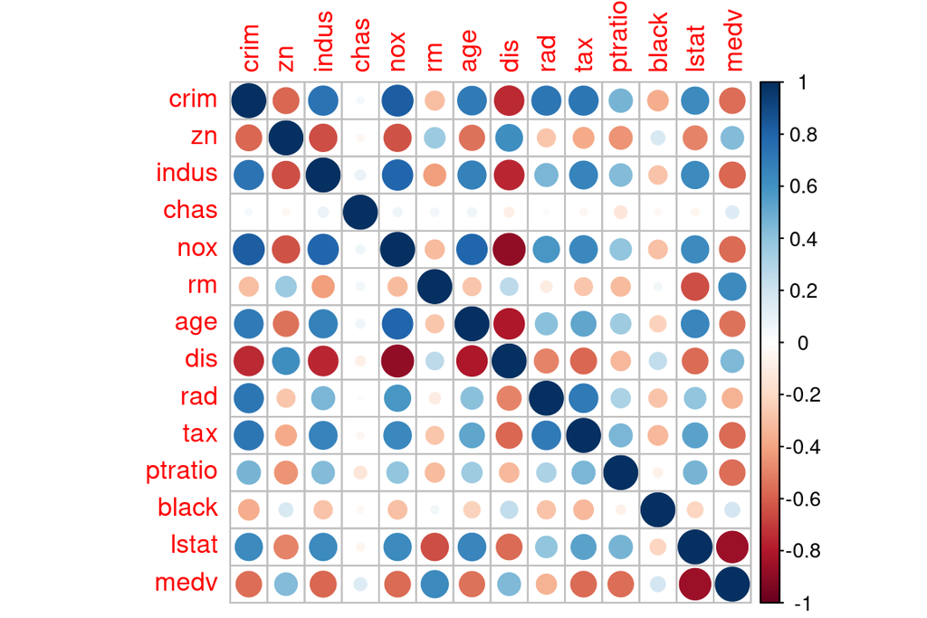

```r
library(GGally)
library(corrplot)
corrplot(cor(Boston, method="spearman"), method = "circle")
```

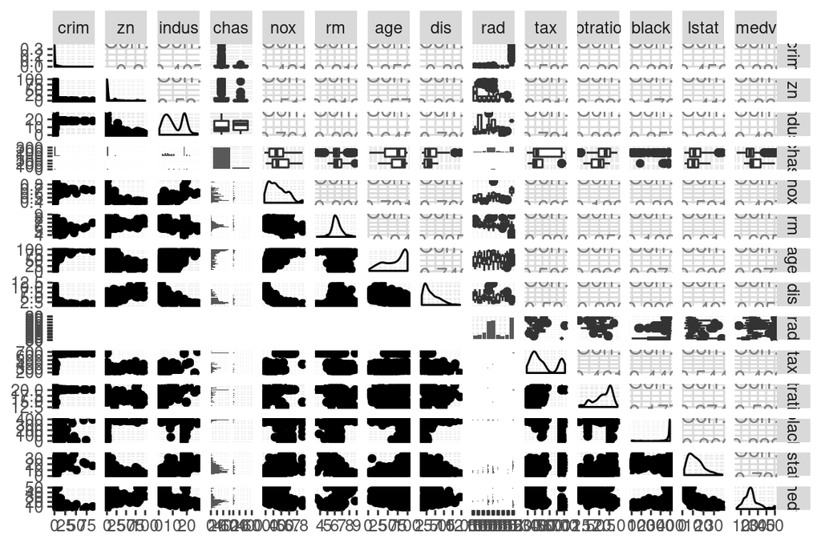

```r
newBost<-Boston
newBost$chas<-as.factor(newBost$chas)
newBost$rad<-as.factor(newBost$rad)
ggpairs(newBost)
```

Many variables seem to have non-normal distribution, many seem even heavy-tailed and few binomial (having two modes, i.e. peaks, such as indus, tax, and rad). Also strong positive and negative correlations are present among several variables.

fLet’s plot density of each variable separately:

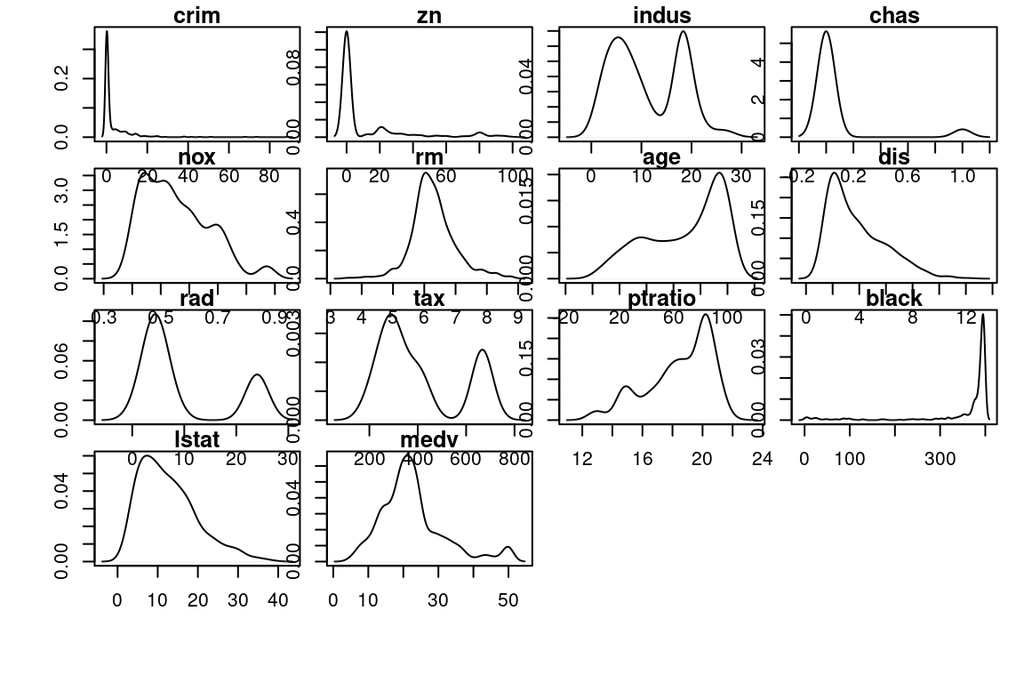

```r
par(mfrow=c(4,4), oma = c(5,4,0,0) + 0.1,
          mar = c(0,0,1,1) + 0.1)
tmp<-lapply(1:ncol(Boston), function(i) plot(density(as.numeric(Boston[,i])), main=colnames(Boston)[i]))
```

And next normalize (scale) these variables to have zero mean and standard deviation of one. This can be somewhat questionable for e.g. heavy-tailed distributions where variance and standard devation may not be defined at all, but it’s requested by the assignment instructions.

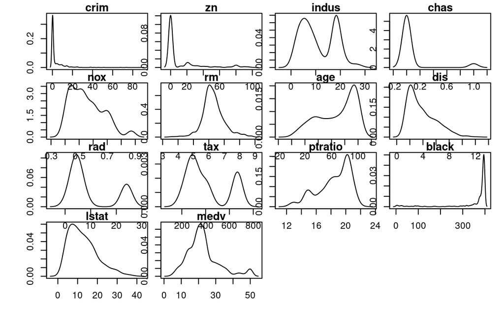

```r
# Scale original variables
newBost<-Boston
newBost<-(apply(newBost, 2, function(col) {
  if (is.numeric(col)) scale(col)
}))

# Plot scaled variable
par(mfrow=c(4,4), oma = c(5,4,0,0) + 0.1,
          mar = c(0,0,1,1) + 0.1)
tmp<-lapply(1:ncol(newBost), function(i) plot(density(as.numeric(Boston[,i])), main=colnames(newBost)[i]))

newBost<-as.data.frame(newBost)
```

Create a factor with quantiles of crim (and replace original variable). Let’s also do a 80:20 split of the dataset, by creating a holdout indicator.

```r
newBost$crim<-with(newBost, cut(crim, quantile(crim, c(0, 0.25, 0.5, 0.75, 1)), labels = c("Q1", "Q2", "Q3", "Q4")))

holdout<-rbinom(n = nrow(newBost), size = 1, prob = 0.2)
print(table(holdout))
```

```
## holdout
##   0   1
## 393 113
```

```r
trainset<-newBost[holdout==0,]
testset<-newBost[holdout==1,]
```

# LDA

Estimate model using trainset, predict in testset (remove original) and compare to original crim in testset. Crosstabulate predictions with original values.

```r
library(MASS)
mod1<-lda(crim~., data=trainset)

test_crim<-testset$crim
testset$crim<-predict(mod1, newdata=testset)$class

table(test_crim, testset$crim)
```

```
##
## test_crim Q1 Q2 Q3 Q4
##        Q1 13 17  3  0
##        Q2  3 13 10  0
##        Q3  0  5 25  0
##        Q4  0  0  0 24
```

```r
cat(paste("Test error rate:", round(mean(test_crim != testset$crim)*100, 1), "%"))
```

```
## Test error rate: 33.6 %
```

# K-means clustering

Reload boston and rescale. Sum of squares to find right number of clusters:

```r
# Reload Boston and rescale
newBost<-Boston
newBost<-(apply(newBost, 2, function(col) {
  if (is.numeric(col)) scale(col)
}))

wss <- sapply(1:20,
              function(k){kmeans(newBost, k, nstart=50, iter.max = 15)$tot.withinss})
wss
```

```
##  [1] 7070.000 4576.681 3871.374 3445.946 3074.612 2723.217 2436.911
##  [8] 2248.218 2064.030 1940.011 1849.925 1729.998 1659.495 1598.493
## [15] 1544.558 1476.380 1426.614 1385.056 1333.214 1286.531
```

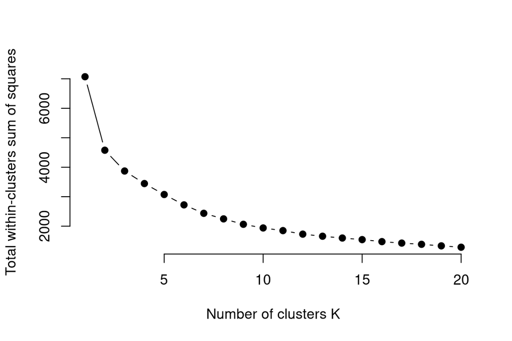

```r
plot(1:20, wss,
     type="b", pch = 19, frame = FALSE,
     xlab="Number of clusters K",
     ylab="Total within-clusters sum of squares")
```

This approach does’t seem to give any insight. Let’s try Gap statistic:

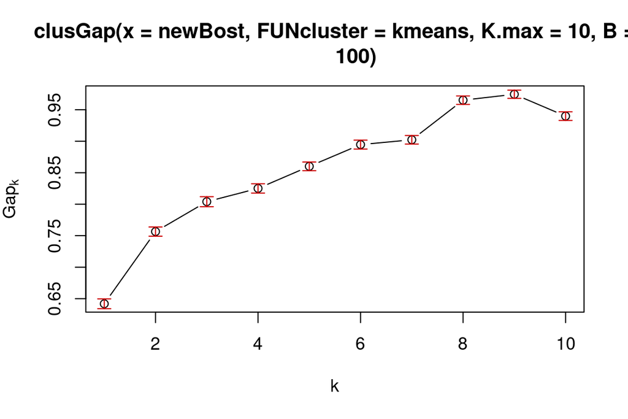

```r
library(cluster)
cg<-clusGap(newBost, kmeans, 10, B = 100)
plot(cg)
```

This approach suggest nine (although increasing number to significantly higher levels could be argued). Let’s build a kmeans clustering model with nine clusters and plot that:

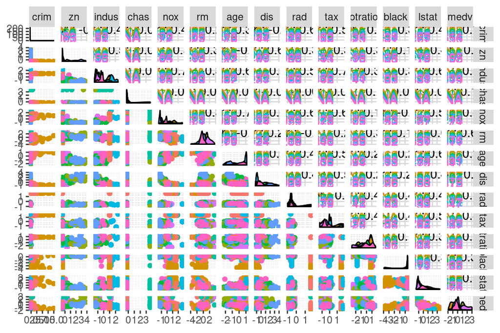

```r
km1<-kmeans(newBost, 9)
ggpairs(as.data.frame(newBost), aes(col=as.factor(km1$cluster)))
```